## Binational community transmission.

At border cities in the Sonora Arizona region such as Nogales, the first covid19 case was reported on March 31st. A 65 years old lady that visited the city of Phoenix, Az. and returned to the Mexican side on March 16th. After 6 days of her return, she stated to develop symptoms.

It took fifteen days to detect this patient. This case shows a **critical time frame** for diagnosis and the potential for local spreading the virus.

Living at the border in a viral pandemic situation means sharing a common path for transmission. While the evidence of local community transmission at the Arizona Sonora Border region has beginning to emerge, social distancing measures continue to be strengthened.

#### Tracing Travel path. First covid19 patient. Nogales,Sonora.

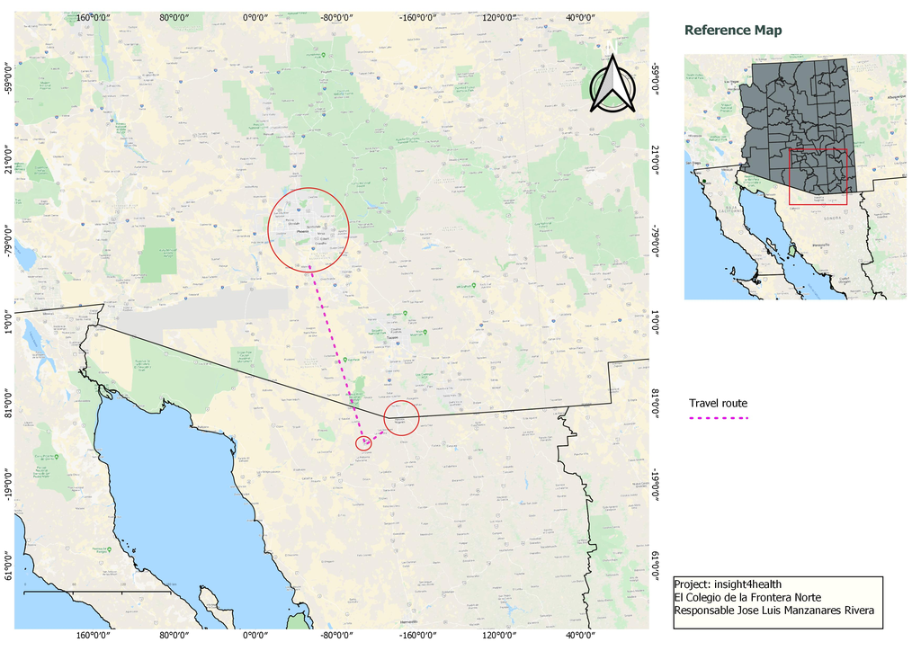

First covid case Nogales, Sonora

## First covid19 death at the Sonora border.

On Monday, **March 30th**, the first Sonora covid19 death was recorded in the border city of Nogales, Sonora.

- **Age:** 29 years old.
- **Sex:** Female.
- **known comorbilities:** Diabetes.
- **Hospitalization date:** March 28, 2020.
- **Hospitalization site:** IMSS, Nogales Sonora.
- **Residence place:** Magdalena de Kino, Sonora.
- **Symptoms onset:** March, 22, 2020
- **deathdate:** March, 30, 2020
- **Diagnóstic confirmation:** April 4th, 2020

Note diagnosis is confirmed after the patient’s death.

This case shows the response capacity of the Mexican health system.

The **6-day** period elapsed between the day of onset of symptoms and the date of hospitalization is critical to the prognosis of this patient.

Furthermore, a diagnosis confirmation after the patient’s death, shows the weakness of the local health system in the face of this global public health threat as well as the importance of the preventive containment strategy implemented, such as the “Stay at home” guidelines to control the exponential spread of the virus.

For the border population of Sonora, abiding by the recommendations of the health authorities, which in turn are based on [best practices](https://www.abc.net.au/news/2020-03-26/coronavirus-covid19-global-spread-data-explained/12089028) in countries that have managed to maintain lower growth rates in cases of covid19 (such as Japan, Singapur, Taiwan, South Korea) can make the difference to avoid contracting the virus.

This case also highlights the possibility that the virus can be circulating unnoticed in this border region possibly since the beginning of March. The refered patient didn´t present evidence of travel to the US or affected areas. Although Magdalena, Sonora is a known border turist destination where Tucson and Phoenix residents are a common population group in this town located 50 miles from the US border.

### First covid19 death at the Sonora Arizona

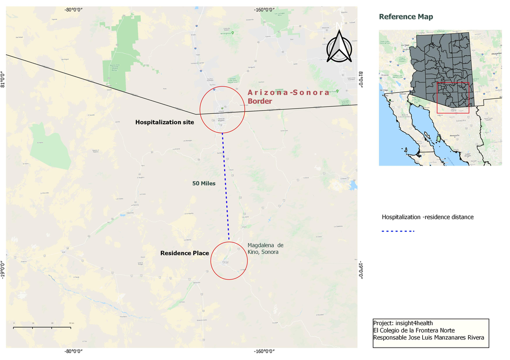

First covid19 death at the Sonora Arizona

Background information on the first confirmed case in the Mexican side of the **Arizona-Sonora** border.